# *The Economist*’s Presidential Election Forecasting Model

Model designed in collaboration with Merlin Heidemanns and Andrew Gelman (Columbia University)

Last update on Monday March 23, 2020 at 11:54 PM EDT

## Methodology

Our forecasting model produces predictions for Democratic and Republican two-party vote share at the state and national level for every day in the election campaign. This section describes the method with which it arrives at those predictions.

Following the model description is a summary of how the method performed in the 2008, 2012 and 2016 presidential elections.

### Structure

It is useful to think of the model as a combination of pre-election polls with other data about election outcomes, sometimes referred to as the “fundamentals” of the campaign. These data translate the president’s popularity and the economic environment into long-range forecasts of the final election outcome, made as early as March and updated throughout the election year. In the Bayesian sense, the model is using state and national polls to update these prior expectations of the political environment.

We are interested not only in the precise vote-share predictions from the model, but also the level of certainty we do(n’t) have in them. The model is thus made up of three different conceptual components:

1. Prior predictions
2. Polling averages
3. Exploration of uncertainty

## Model performance

Select an election for more:

### 2008

#### Map

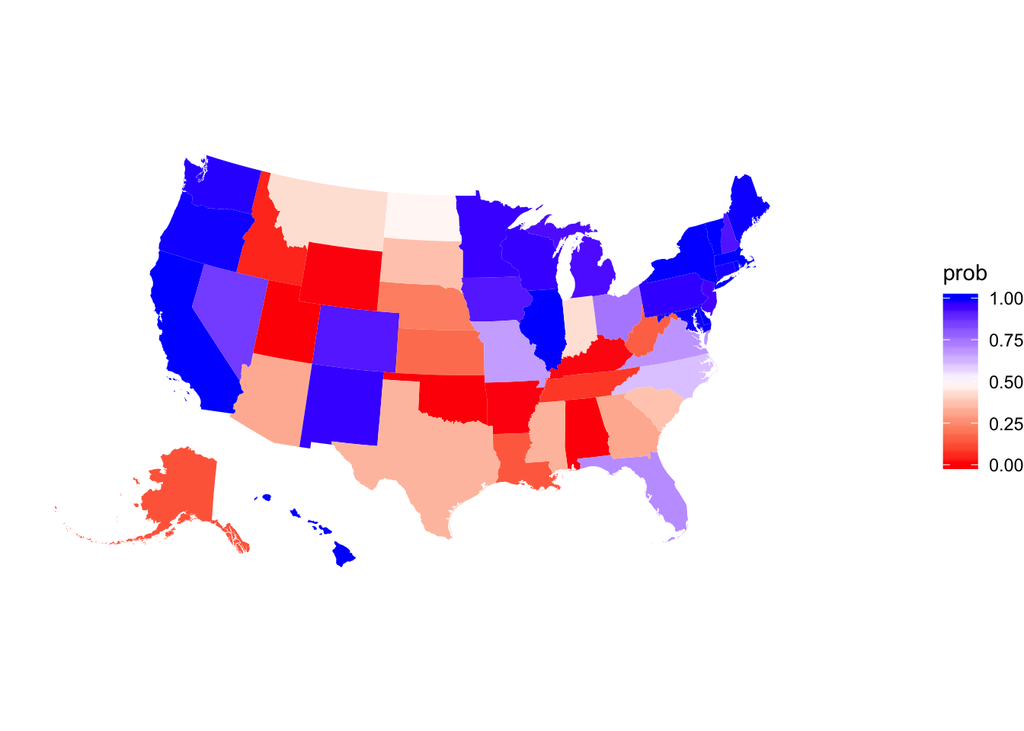

#### Final electoral college histogram

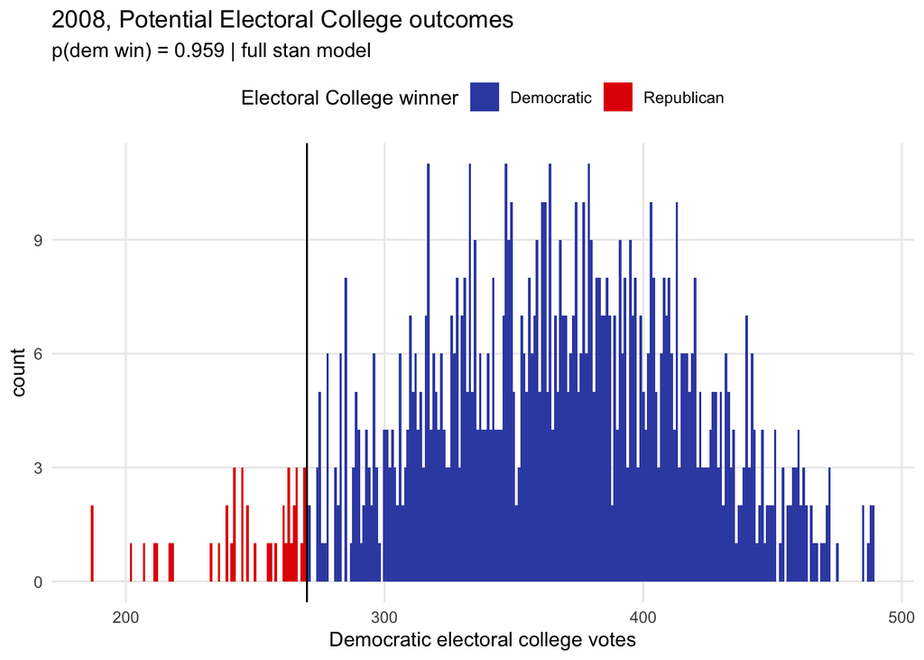

#### National and state polls and the electoral college over time

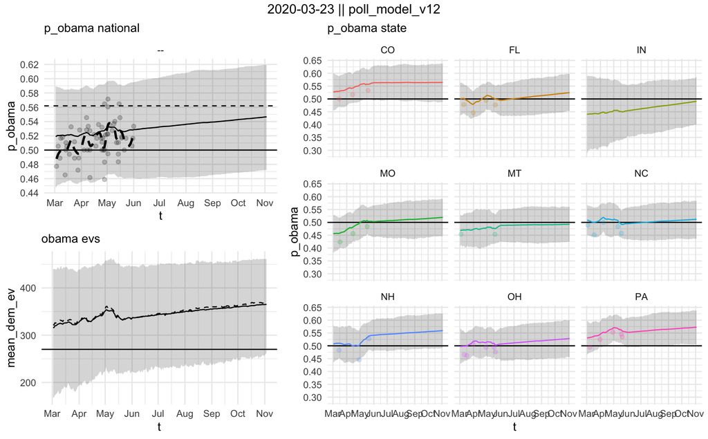

#### State vs national deltas over time

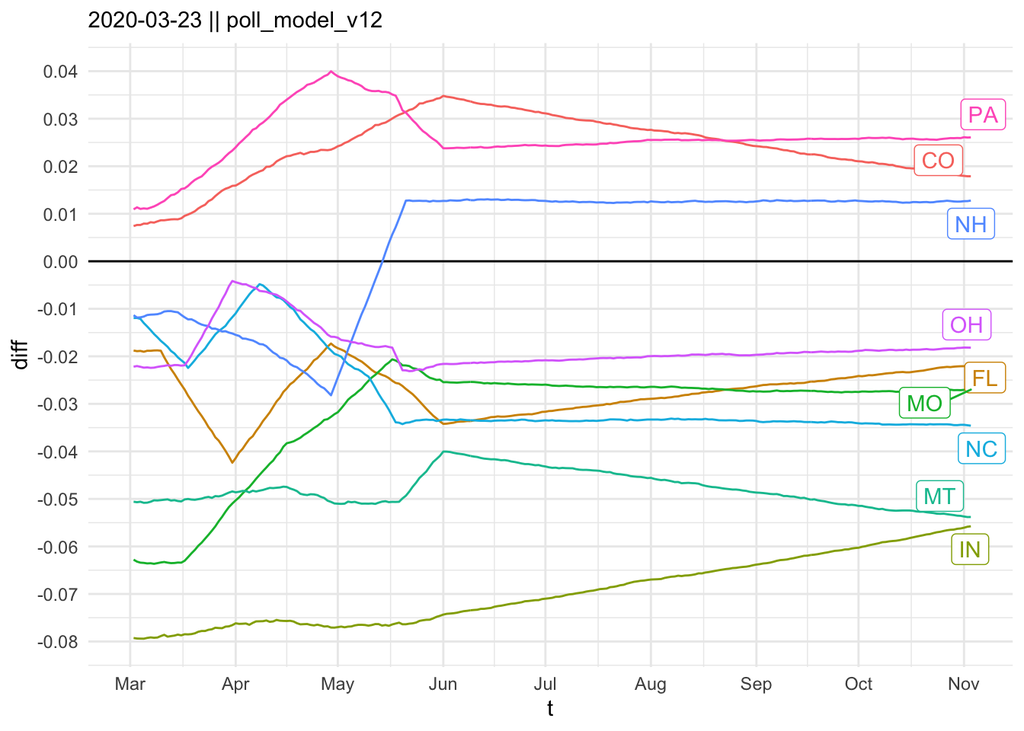

#### Model results vs polls vs the prior

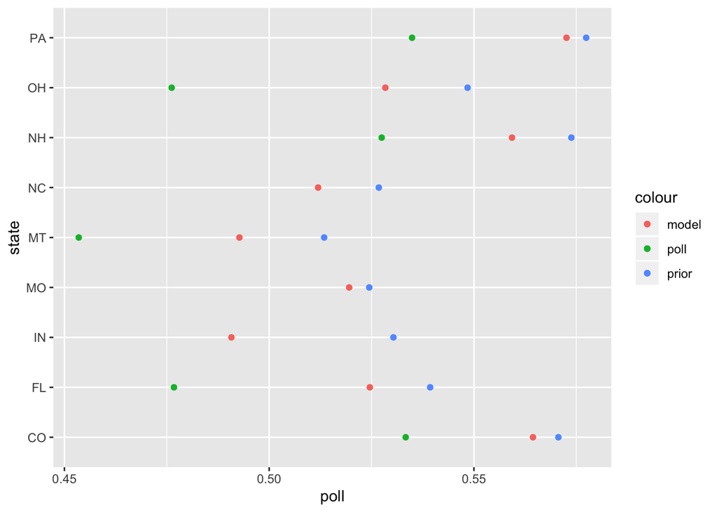

#### Performance

| outlet | ev_wtd_brier | unwtd_brier | states_correct |
| --- | --- | --- | --- |
| economist (backtest) | 0.0509936 | 0.0491446 | 49 |

#### Predictions for each state

|  | state | mean | low | high | prob | se |
| --- | --- | --- | --- | --- | --- | --- |
| 1 | ND | 0.496 | 0.407 | 0.582 | 0.48 | 0.043 |
| 2 | MT | 0.493 | 0.424 | 0.562 | 0.429 | 0.034 |
| 3 | IN | 0.491 | 0.399 | 0.585 | 0.431 | 0.047 |
| 4 | NC | 0.512 | 0.436 | 0.584 | 0.607 | 0.036 |
| 5 | SC | 0.484 | 0.405 | 0.564 | 0.371 | 0.04 |
| 6 | SD | 0.484 | 0.4 | 0.569 | 0.367 | 0.042 |
| 7 | MS | 0.481 | 0.406 | 0.554 | 0.336 | 0.036 |
| 8 | TX | 0.481 | 0.403 | 0.558 | 0.341 | 0.038 |
| 9 | MO | 0.52 | 0.448 | 0.591 | 0.67 | 0.036 |
| 10 | GA | 0.478 | 0.398 | 0.558 | 0.313 | 0.04 |

[output cut: 42 more lines]

### 2012

#### Map

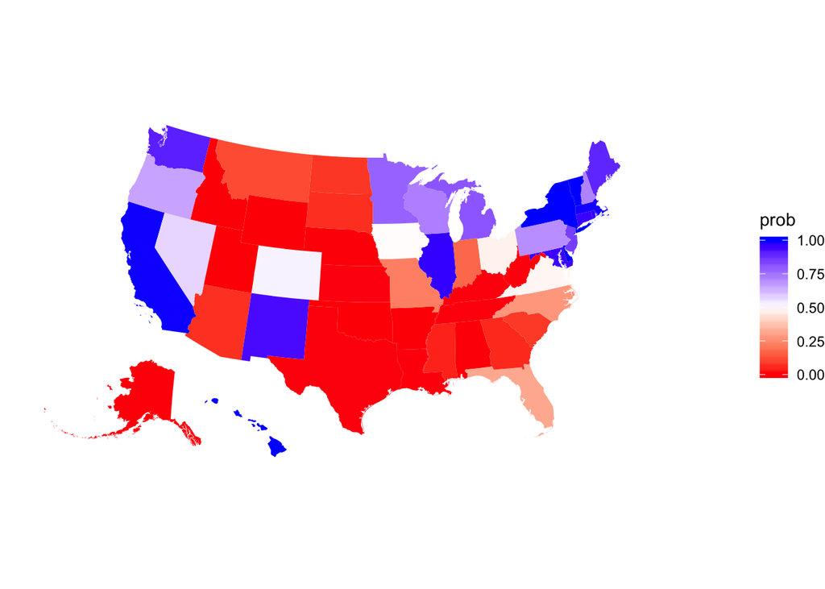

#### Final electoral college histogram

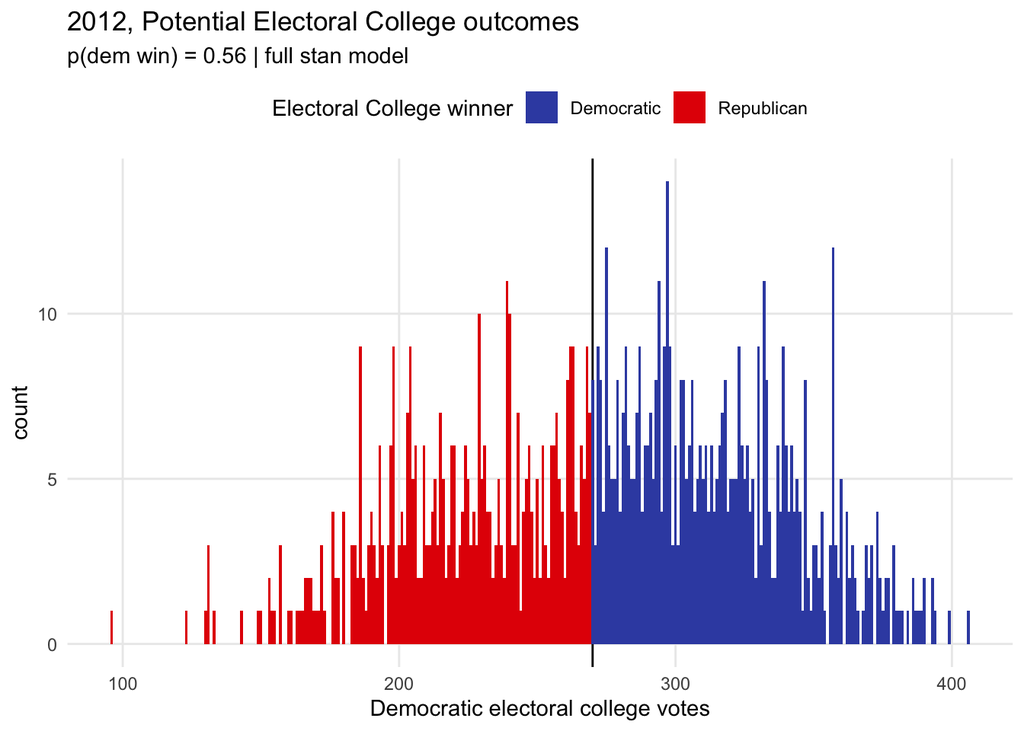

#### National and state polls and the electoral college over time

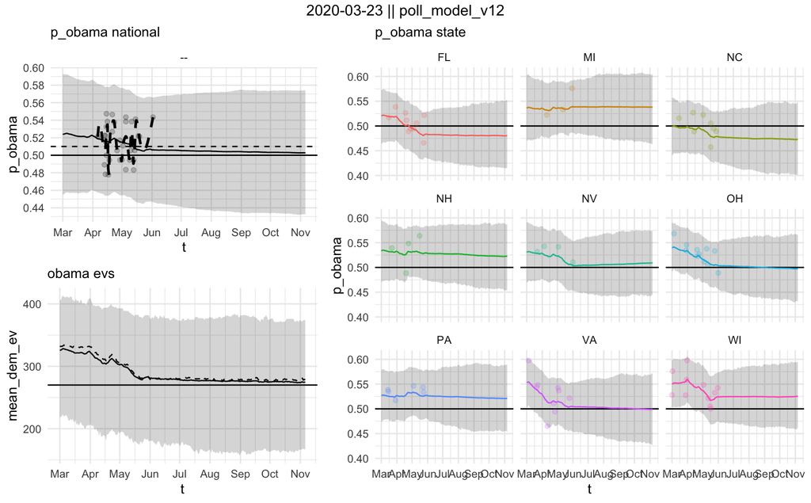

#### State vs national deltas over time

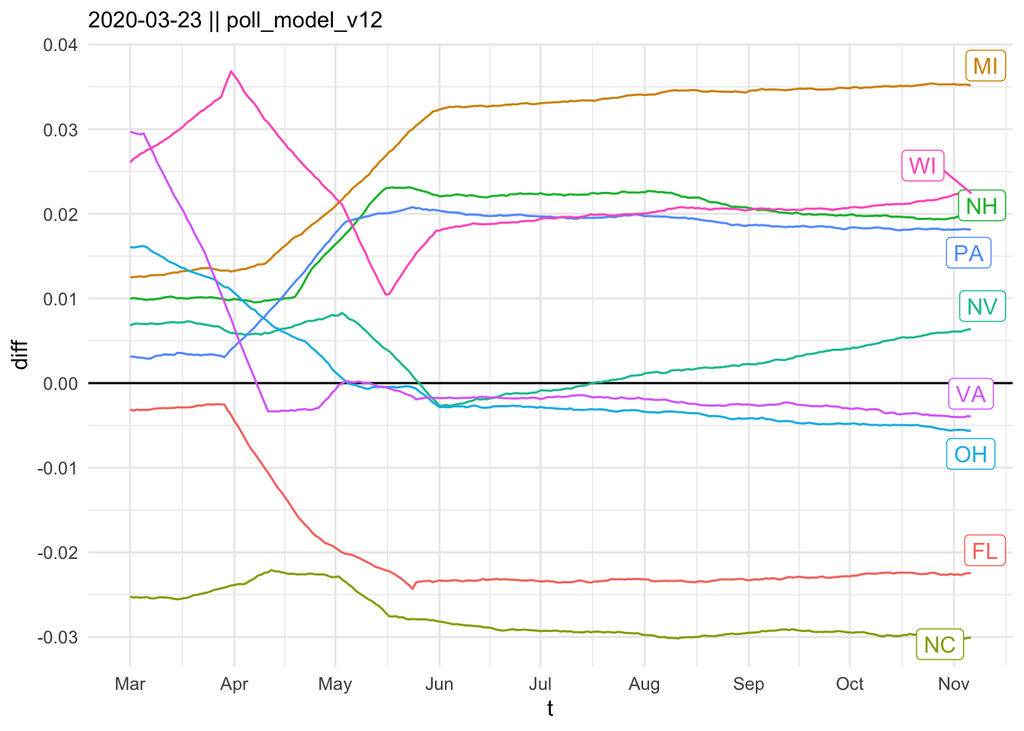

#### Model results vs polls vs the prior

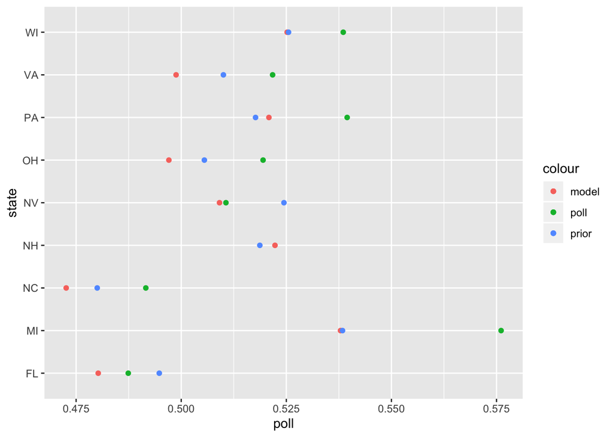

#### Performance

| outlet | ev_wtd_brier | unwtd_brier | states_correct |
| --- | --- | --- | --- |
| Linzer | NA | 0.0038000 | NA |
| Wang/Ferguson | NA | 0.0076100 | NA |
| Silver/538 | NA | 0.0091100 | NA |
| Jackman/Pollster | NA | 0.0097100 | NA |
| Desart/Holbrook | NA | 0.0160500 | NA |
| Intrade | NA | 0.0281200 | NA |
| economist (backtest) | 0.0642578 | 0.0470445 | 47 |
| Enten/Margin of Error | NA | 0.0507500 | NA |

#### Predictions for each state

|  | state | mean | low | high | prob | se |
| --- | --- | --- | --- | --- | --- | --- |
| 1 | IA | 0.499 | 0.435 | 0.562 | 0.495 | 0.032 |
| 2 | VA | 0.499 | 0.428 | 0.571 | 0.48 | 0.036 |
| 3 | CO | 0.502 | 0.436 | 0.569 | 0.521 | 0.033 |
| 4 | OH | 0.497 | 0.432 | 0.565 | 0.473 | 0.034 |
| 5 | -- | 0.503 | 0.433 | 0.574 |  | 0.035 |
| 6 | NV | 0.509 | 0.445 | 0.574 | 0.571 | 0.032 |
| 7 | OR | 0.516 | 0.447 | 0.585 | 0.656 | 0.034 |
| 8 | FL | 0.48 | 0.416 | 0.551 | 0.313 | 0.035 |
| 9 | PA | 0.521 | 0.453 | 0.59 | 0.695 | 0.034 |
| 10 | NH | 0.522 | 0.453 | 0.587 | 0.717 | 0.032 |

[output cut: 42 more lines]

### 2016

#### Map

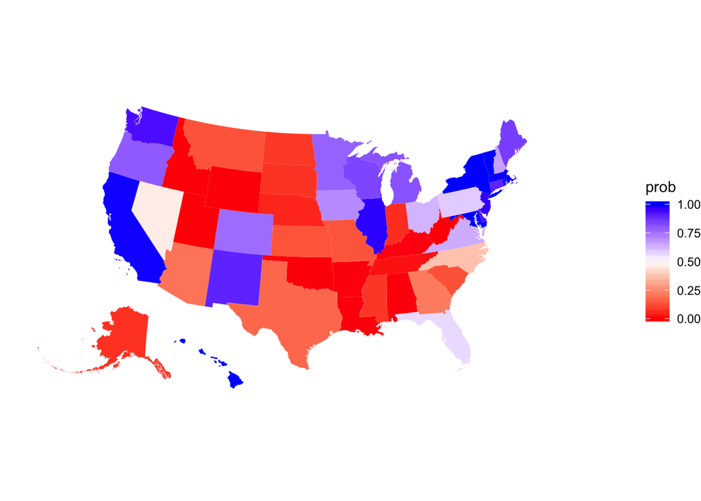

#### Final electoral college histogram

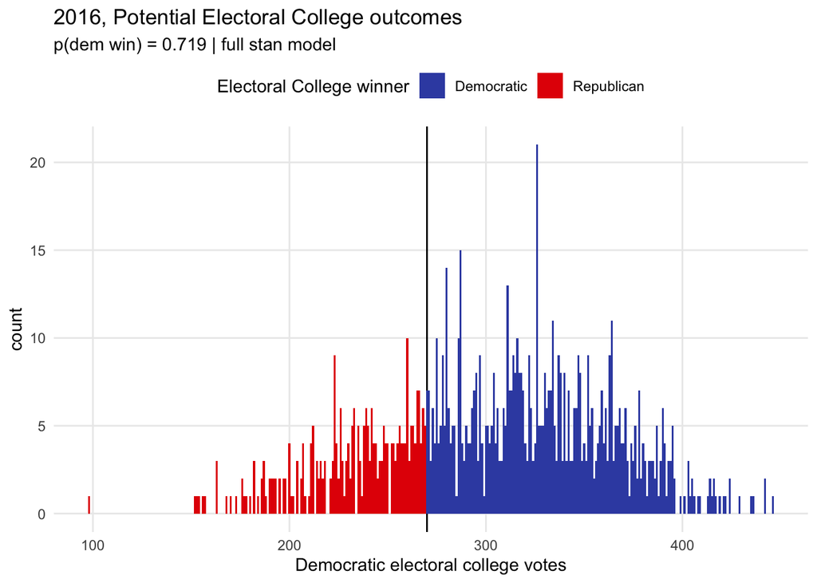

#### National and state polls and the electoral college over time

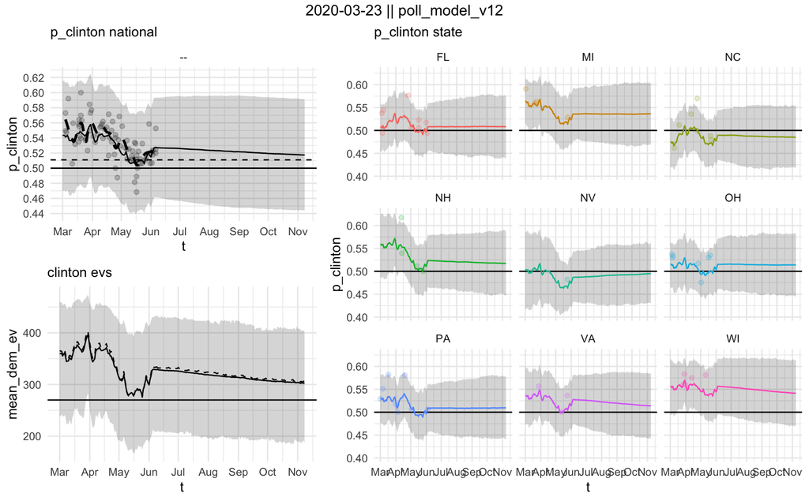

#### State vs national deltas over time

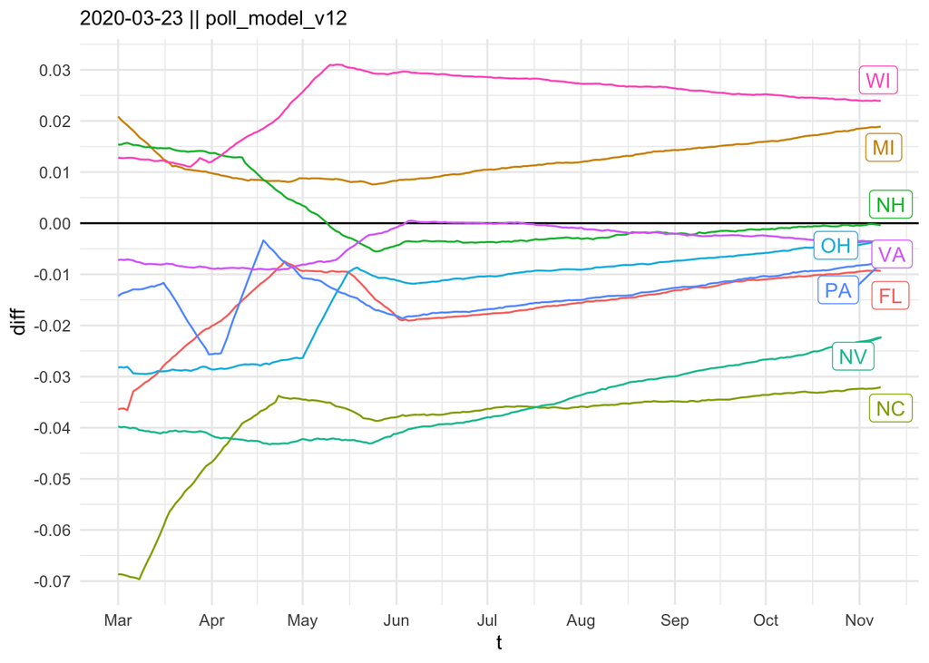

#### Model results vs polls vs the prior

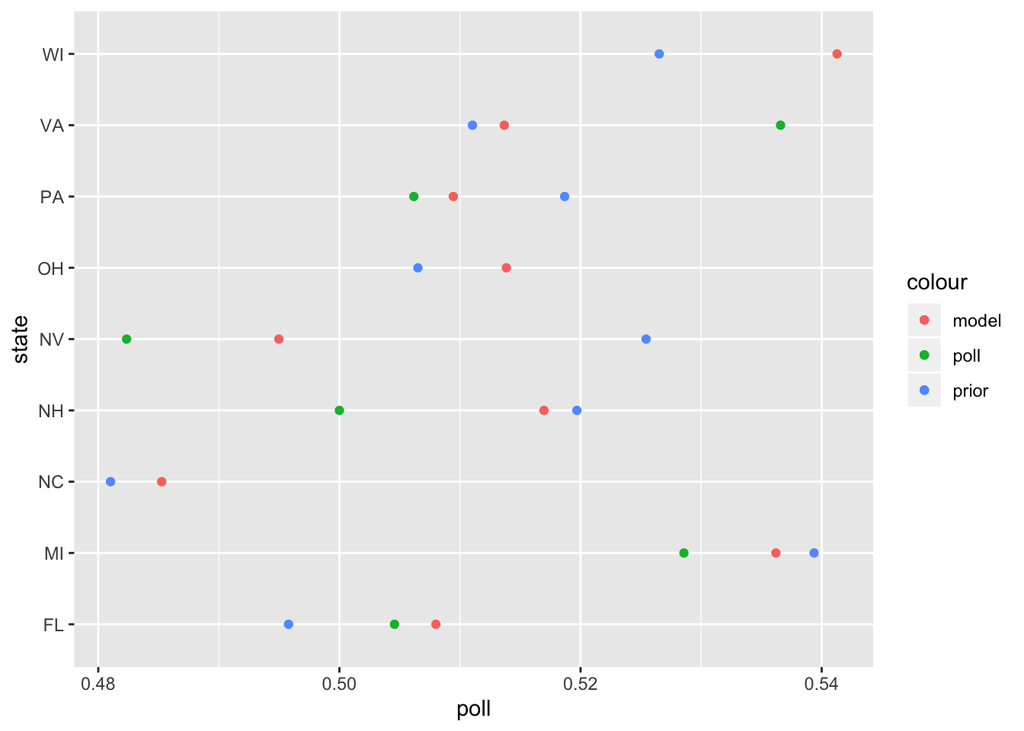

#### Performance

| outlet | ev_wtd_brier | unwtd_brier | states_correct |
| --- | --- | --- | --- |
| 538 polls-plus | 0.0928000 | 0.0664000 | 46 |
| 538 polls-only | 0.0936000 | 0.0672000 | 46 |
| economist (backtest) | 0.1007521 | 0.0783947 | 44 |
| princeton | 0.1169000 | 0.0744000 | 47 |
| nyt upshot | 0.1208000 | 0.0801000 | 46 |
| kremp/slate | 0.1210000 | 0.0766000 | 46 |
| pollsavvy | 0.1219000 | 0.0794000 | 46 |
| predictwise markets | 0.1272000 | 0.0767000 | 46 |
| predictwise overall | 0.1276000 | 0.0783000 | 46 |
| desart and holbrook | 0.1279000 | 0.0825000 | 44 |
| daily kos | 0.1439000 | 0.0864000 | 46 |
| huffpost | 0.1505000 | 0.0892000 | 46 |

#### Predictions for each state

|  | state | mean | low | high | prob | se |
| --- | --- | --- | --- | --- | --- | --- |
| 1 | NV | 0.495 | 0.432 | 0.563 | 0.461 | 0.034 |
| 2 | FL | 0.508 | 0.439 | 0.574 | 0.564 | 0.033 |
| 3 | PA | 0.509 | 0.441 | 0.578 | 0.587 | 0.034 |
| 4 | OH | 0.514 | 0.446 | 0.583 | 0.628 | 0.035 |
| 5 | VA | 0.514 | 0.443 | 0.584 | 0.641 | 0.035 |
| 6 | NC | 0.485 | 0.419 | 0.553 | 0.37 | 0.034 |
| 7 | NH | 0.517 | 0.446 | 0.588 | 0.663 | 0.036 |
| 8 | -- | 0.517 | 0.444 | 0.591 |  | 0.037 |
| 9 | IA | 0.528 | 0.439 | 0.618 | 0.703 | 0.045 |
| 10 | AZ | 0.468 | 0.401 | 0.535 | 0.2 | 0.033 |

[output cut: 42 more lines]